# SR_01_DISREG_ENTITY_EIN

Disregarded entity EIN · Identifier report

## Overview

**Description**

Form990 Schedule RPart I - EIN

**Table**

`SR-P01-T01-ID-DISREGARDED-ENTITIES` (many)

**Location code**

`SCHED-R-PART-01-COL-A`

**Family**

`SCHED-R-PART-01-COL-A` · siblings: SR_01_DISREG_ENTITY_ADDR_CITY, SR_01_DISREG_ENTITY_ADDR_CNTR, SR_01_DISREG_ENTITY_ADDR_L1, SR_01_DISREG_ENTITY_ADDR_L2, SR_01_DISREG_ENTITY_ADDR_STATE, SR_01_DISREG_ENTITY_ADDR_ZIP

**Data type**

numeric (xsd: EINType)

**Scope**

PC

**Status**

unreviewed

2

xpaths mapped (2 observed)

99,377

filings with a value

2009–2024

tax years observed

2

open flags (0 errors)

## Flags

| Severity | Flag | Xpath | Detail |
| --- | --- | --- | --- |
| ⓘ info | `MANY_NOT_REPEATING` | IRS990ScheduleR/IdDisregardedEntitiesGrp/EIN | many-to-one table, but 55% of values sit in no repeating element |
| ⓘ info | `MANY_NOT_REPEATING` | IRS990ScheduleR/Form990ScheduleRPartI/EIN | many-to-one table, but 56% of values sit in no repeating element |

## Xpaths

All mapped xpaths (under /Return/ReturnData or /Return/ReturnHeader), oldest first. Charts label each series by its xpath.

[output not shown]

## Coverage

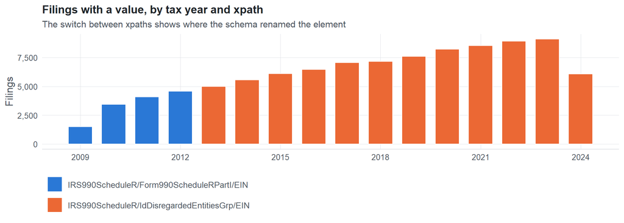

**Table view**

Table view: filings by tax year and series

| Tax year | IRS990ScheduleR/Form990ScheduleRPartI/EIN | IRS990ScheduleR/IdDisregardedEntitiesGrp/EIN |
| --- | --- | --- |
| 2009 | 1,506 | 0 |
| 2010 | 3,442 | 0 |
| 2011 | 4,077 | 0 |
| 2012 | 4,564 | 0 |
| 2013 | 0 | 4,977 |
| 2014 | 0 | 5,569 |
| 2015 | 0 | 6,096 |
| 2016 | 0 | 6,458 |
| 2017 | 0 | 7,057 |
| 2018 | 0 | 7,157 |
| 2019 | 0 | 7,611 |
| 2020 | 0 | 8,222 |
| 2021 | 0 | 8,543 |
| 2022 | 0 | 8,923 |
| 2023 | 0 | 9,095 |
| 2024 | 0 | 6,080 |

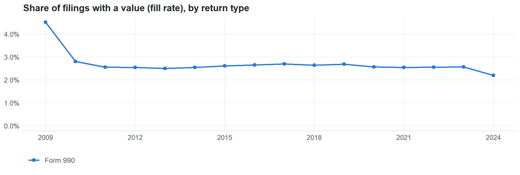

**Table view**

Table view: fill rate

| Tax year | Return type | Filings | All filings | Fill rate |
| --- | --- | --- | --- | --- |
| 2009 | Form 990 | 1,506 | 33,311 | 4.52% |
| 2010 | Form 990 | 3,442 | 123,025 | 2.80% |
| 2011 | Form 990 | 4,077 | 159,504 | 2.56% |
| 2012 | Form 990 | 4,564 | 179,688 | 2.54% |
| 2013 | Form 990 | 4,977 | 198,855 | 2.50% |
| 2014 | Form 990 | 5,569 | 218,619 | 2.55% |
| 2015 | Form 990 | 6,096 | 233,519 | 2.61% |
| 2016 | Form 990 | 6,458 | 243,903 | 2.65% |
| 2017 | Form 990 | 7,057 | 261,612 | 2.70% |
| 2018 | Form 990 | 7,157 | 271,442 | 2.64% |
| 2019 | Form 990 | 7,611 | 283,694 | 2.68% |
| 2020 | Form 990 | 8,222 | 320,342 | 2.57% |
| 2021 | Form 990 | 8,543 | 336,480 | 2.54% |
| 2022 | Form 990 | 8,923 | 349,055 | 2.56% |
| 2023 | Form 990 | 9,095 | 354,768 | 2.56% |
| 2024 | Form 990 | 6,080 | 277,298 | 2.19% |

## Repeating groups

Table cardinality in the concordance: **many**. 2 of 2 observed xpaths repeat within a filing.

Repeating element each xpath was observed in (from the raw indexed xpath)

| Xpath | Repeating element | Filings (summed over years) |
| --- | --- | --- |
| IRS990ScheduleR/Form990ScheduleRPartI/EIN | (none) | 7638 |
| IRS990ScheduleR/Form990ScheduleRPartI/EIN | IRS990ScheduleR/Form990ScheduleRPartI | 5951 |
| IRS990ScheduleR/IdDisregardedEntitiesGrp/EIN | (none) | 47338 |
| IRS990ScheduleR/IdDisregardedEntitiesGrp/EIN | IRS990ScheduleR/IdDisregardedEntitiesGrp | 38450 |

## Values

| Result | Check | Detail |
| --- | --- | --- |
| ✓ pass | Values have the EIN format | 100.0% of values match ^999999999$ |
| ⚠ fail | Stored as text | data type is numeric: leading zeros and letters would be lost |
| ▲ warn | No placeholder values | 134 filings use a placeholder such as 000000000 |
| ⓘ info | Leading zeros present | at least 1% of values start with 0 in some year, so numeric storage would change them |

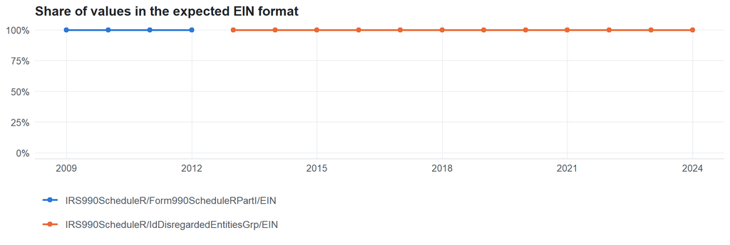

Value shapes (9 = digit, A = letter)

| Series | Shape | Expected | Filings |
| --- | --- | --- | --- |
| IRS990ScheduleR/Form990ScheduleRPartI/EIN | 999999999 | yes | 13,589 |
| IRS990ScheduleR/IdDisregardedEntitiesGrp/EIN | 999999999 | yes | 85,788 |

## Examples

| Tax year | Return | Xpath | Organization | Value | Source |
| --- | --- | --- | --- | --- | --- |
| 2024 | 990 | IRS990ScheduleR/IdDisregardedEntitiesGrp/EIN | THE CLEVELAND CLINIC FOUNDATION | 842380272 | [XML](https://gt990datalake-rawdata.s3.amazonaws.com/EfileData/XmlFiles/202513189349302136_public.xml) |
| 2023 | 990 | IRS990ScheduleR/IdDisregardedEntitiesGrp/EIN | ST BERNARD VOLUNTEERS OF AMERICA | 852041412 | [XML](https://gt990datalake-rawdata.s3.amazonaws.com/EfileData/XmlFiles/202403109349303120_public.xml) |
| 2022 | 990 | IRS990ScheduleR/IdDisregardedEntitiesGrp/EIN | FITTON CENTER FOR CREATIVE ARTS | 562521927 | [XML](https://gt990datalake-rawdata.s3.amazonaws.com/EfileData/XmlFiles/202401279349302985_public.xml) |
| 2021 | 990 | IRS990ScheduleR/IdDisregardedEntitiesGrp/EIN | POLK CDC | 260030062 | [XML](https://gt990datalake-rawdata.s3.amazonaws.com/EfileData/XmlFiles/202300679349300330_public.xml) |
| 2020 | 990 | IRS990ScheduleR/IdDisregardedEntitiesGrp/EIN | VOLUNTEERS OF AMERICA INC | 814333468 | [XML](https://gt990datalake-rawdata.s3.amazonaws.com/EfileData/XmlFiles/202133159349302793_public.xml) |
| 2019 | 990 | IRS990ScheduleR/IdDisregardedEntitiesGrp/EIN | NOSOTROS INC | 680509127 | [XML](https://gt990datalake-rawdata.s3.amazonaws.com/EfileData/XmlFiles/202141269349301229_public.xml) |
| 2018 | 990 | IRS990ScheduleR/IdDisregardedEntitiesGrp/EIN | HOUSTON RHF HOUSING INC | 472131303 | [XML](https://gt990datalake-rawdata.s3.amazonaws.com/EfileData/XmlFiles/201932269349301433_public.xml) |
| 2017 | 990 | IRS990ScheduleR/IdDisregardedEntitiesGrp/EIN | TELACU SENIOR COURT INC | 952870267 | [XML](https://gt990datalake-rawdata.s3.amazonaws.com/EfileData/XmlFiles/201832849349301128_public.xml) |
| 2016 | 990 | IRS990ScheduleR/IdDisregardedEntitiesGrp/EIN | COMMUNITY BUILD INC | 813830032 | [XML](https://gt990datalake-rawdata.s3.amazonaws.com/EfileData/XmlFiles/201822269349302072_public.xml) |
| 2015 | 990 | IRS990ScheduleR/IdDisregardedEntitiesGrp/EIN | THE RAPE FOUNDATION | 262955374 | [XML](https://gt990datalake-rawdata.s3.amazonaws.com/EfileData/XmlFiles/201603499349301140_public.xml) |
| 2014 | 990 | IRS990ScheduleR/IdDisregardedEntitiesGrp/EIN | United States Tennis Association Incorporated | 200984914 | [XML](https://gt990datalake-rawdata.s3.amazonaws.com/EfileData/XmlFiles/201503209349310100_public.xml) |
| 2013 | 990 | IRS990ScheduleR/IdDisregardedEntitiesGrp/EIN | ST CLAIR COUNTRY CLUB | 256582600 | [XML](https://gt990datalake-rawdata.s3.amazonaws.com/EfileData/XmlFiles/201500409349300790_public.xml) |

## Reviewer checklist

- The definition matches the form line and instructions for every xpath’s schema years.
- Every xpath pooled here measures the same thing on the 990 and 990-EZ (close enough for analysis).
- The coverage chart has no unexplained gaps or jumps between tax years.
- Each open flag is fixed, or accepted with a note in validation_log.csv.
- The data type is text so leading zeros and letters survive.
- The identifier belongs to the entity the variable names (the filer, preparer, related organization…).
- Formats with and without punctuation (e.g. ZIP+4, dashes) are normalized consistently downstream.

Record the review as a row in `inst/extdata/src/validation_log.csv` (variable_name, reviewer, date, status, note). Evidence built 2026-09-23 17:09:04 MST from the ef2 DuckDB builds (tax years 2009–2024).